# VSCode for Python

Date: 15.03.2024  
Lecturers: Harald Kristen & Matthias Wecht

## Setup VSCode with Conda + Jupyter Extension

**Goal:** Set up Visual Studio Code (VSCode) on your local machine with Miniconda and Jupyter for geospatial programming on Windows. Follow these steps:

### Step 1: Install Visual Studio Code

1. Download and install latest Visual Studio Code from the official website: [VSCode Download](https://code.visualstudio.com/download)

### Step 2: Install Miniconda

1. Download the Miniconda installer for Windows from the official Miniconda website: [Miniconda Download](https://docs.conda.io/en/latest/miniconda.html#windows)
2. Run the installer and follow the on-screen instructions. During installation, make sure to check the box that says "Add Miniconda3 to my PATH environment variable."

### Step 3: Open VSCode

1. Open Visual Studio Code after installation.

### Step 4: Install the Python Extension

1. In VSCode, go to the Extensions view by clicking on the Extensions icon in the Activity Bar on the side of the window or press `Ctrl+Shift+X`.
2. Search for "Python" in the Extensions view search box.
3. Install the "Python" extension provided by Microsoft.

### Step 5: Create a Conda Environment

1. Open a new terminal in VSCode.
2. Run the following command to create a new conda environment:

   ```
   conda create --name geospatial python=3.11
   ```

3. Activate the environment: In VSCODE search “> python interpreter” -> select python interpreter

   ```
   conda activate geospatial
   ```

### Step 6: Add working directory to workspace

1. Create a folder on your machine that you will use as parent folder for the whole course = this is your working directory
2. In VSCode go to "File -> Add Folder to Workspace" and add this folder.
3. Download material for this lecture from the EGM 2024 Moodle course to you working directory.

### Step 7: Install Jupyter + Jupyter Kernel for VSCode

In order to display, edit & execute from Jupyter notebooks we need to install the IPython Kernel within VSCode.

1. Open extensions left side menu or type "Crtl+Shift+X"
2. Search for Jupyter and install from VSCode
3. Open this Notebook from your working directory and try to run next codeblock, if it prints Hello World you where successful

```python
print('Hello World')
```

```
Hello World
```

## How to use VSCODE

This part follows the official documentation, for more detailed insights go here: [Python Quickstart](https://code.visualstudio.com/docs/python/python-quick-start), [VSCode User Interface](https://code.visualstudio.com/docs/getstarted/userinterface), [Jupyter Notebooks in VSCode](https://code.visualstudio.com/docs/datascience/jupyter-notebooks).

### User Interface

The UI is divided into five main areas:

- **Editor** - The main area to edit your files. You can open as many editors as you like side by side vertically and horizontally.
- **Primary Side Bar** - Contains different views like the Explorer to assist you while working on your project.
- **Status Bar** - Information about the opened project and the files you edit.
- **Activity Bar** - Located on the far left-hand side, this lets you switch between views and gives you additional context-specific indicators, like the number of outgoing changes when Git is enabled.
- **Panel** - An additional space for views below the editor region. By default, it houses output, debug information, errors and warnings, and an integrated terminal. Panel can also be moved to the left or right for more vertical space.

Each time you start VS Code, it opens up in the same state it was in when you last closed it. The folder, layout, and opened files are preserved.

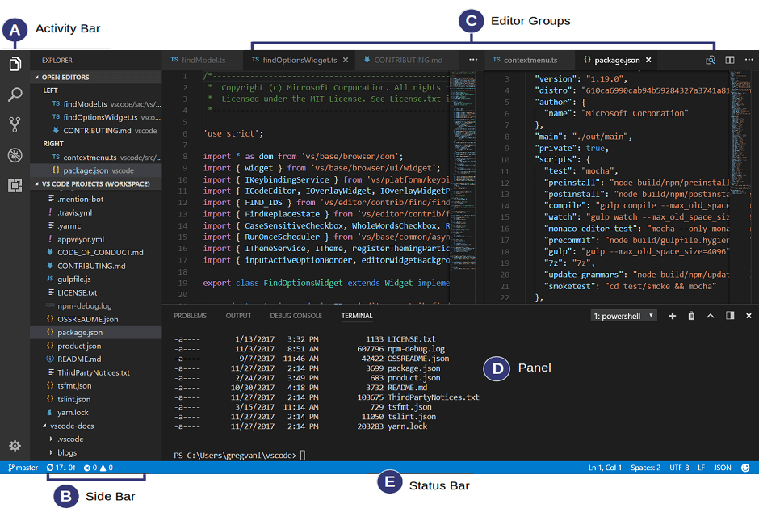

### Side by side editing

You can open as many editors as you like side by side vertically and horizontally. If you already have one editor open, there are multiple ways of opening another editor to the side of the existing one:

- `Alt` click on a file in the Explorer.
- `Ctrl+\` to split the active editor into two.
- **Open to the Side** (`Ctrl+Enter`) from the Explorer context menu on a file.
- Click the **Split Editor** button in the upper right of an editor.
- Drag and drop a file to any side of the editor region.
- `Ctrl+Enter` in the **Quick Open** (`Ctrl+P`) file list.

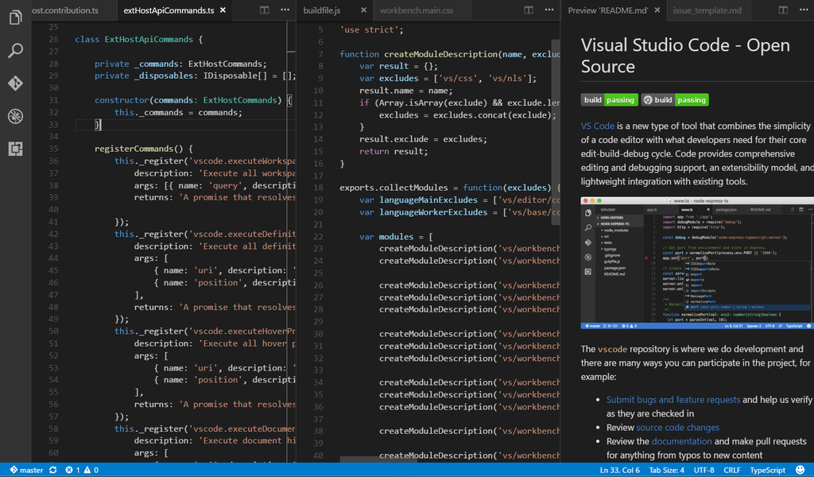

The **Command Palette** provides access to many commands. You can execute editor commands, open files, search for symbols, and see a quick outline of a file, all using the same interactive window. Here are a few tips:

- `Ctrl+P` will let you navigate to any file or symbol by typing its name
- `Ctrl+Tab` will cycle you through the last set of files opened
- `Ctrl+Shift+P` will bring you directly to the editor commands, or just type **">"** in the searchbar.

Type `?` into the input field to get a list of available commands you can execute from here:

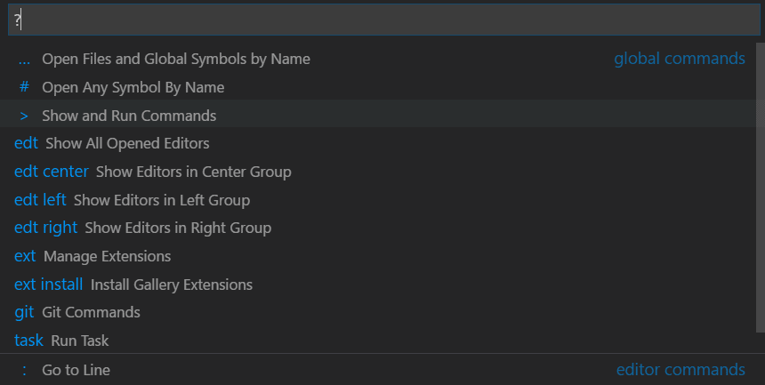

### VSCode Python interface

The UI changes slightly when we install the Python Extension for VSCode, giving us additional features:

[figure not shown]

Python commands can be accessed through the Command Palette (Ctrl+Shift+P). From the Command Palette, you have access to various features from VS Code and installed extensions. Enter “Python: “ in the Command Palette to find the commands available through the Python extension.

[figure not shown]

#### Run

To run the Python script you have open on the editor, select the Run Python File in Terminal play button in the top-right of the editor.

[figure not shown]

#### Debug

The debugger is a helpful tool that allows you to inspect the flow of your code execution and more easily identify errors, as well as explore how your variables and data change as your program is run. You can start debugging by setting a breakpoint in your Python project by clicking in the gutter next to the line you wish to inspect.

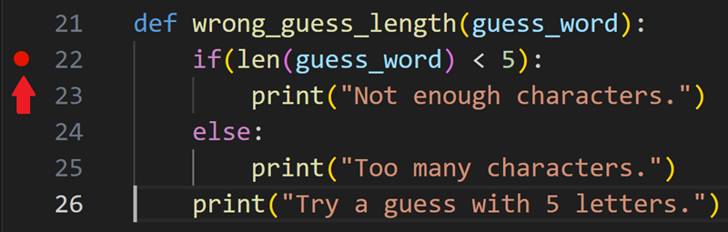

To start debugging, initialize the debugger by pressing F5. Since this is your first time debugging this file, a configuration menu will open allowing you to select the type of application you want to debug. If it's a Python script, you can select Python File.

Once your program reaches the breakpoint, it will stop and allow you to track data in the Python Debug console, and progress through your program using the debug toolbar.

[figure not shown]

For a deeper dive into Python debugging functionality, see [Python debugging in VS Code](https://code.visualstudio.com/docs/python/debugging).

## Getting to know Notebooks

There are two types of cells in a Notebook:

- Code cells
- Text cells

#### Text cells

Text cells or *markdown cells* contain markdown text. That's text that isn't read as Python code. Instead, you can format markdown text to look nice. These text cells help us to give our Notebooks structure, add addtional information on how we did things, link image etc. They are one of they key elements why Notebooks are great for teaching :)

Double-click on this cell to see the markdown text underneath. Running a markdown cell turns it into pretty, formatted text (see on the right side)

- here's a bullet point
- and **another** list item in *italics* and **bold**.
- this is a hyperlink to [Uni Graz Online](https://online.uni-graz.at)
- You can even embed images

#### Try it yourself

Double-click on this cell to see the code that formats this text. Make a few edits and press shift+ENTER to see the changes.

Read more about [formatting the markdown text](https://help.github.com/articles/basic-writing-and-formatting-syntax/) in a cell, like this one, or go to Help > Markdown > Basic Writing and Formatting Text.

### Notebook Shortcuts

Move across cells with `UP` and `DOWN` arrow keys

With `Enter` you can start editing a cell

`Shift + Enter` -> execute one cell

`Ctrl + Shift + Enter` -> execute multiple cell

`ESC` -> Exit current cell

`a` -> create code cell before current cell

`b` -> create code cell after current cell

`x` -> delete code cell

`ALT + ArrowKey` -> move cell up/down

More shortcuts can be found under `Help -> Keyboard Shortcut Reference`

### Jupyter Notebooks in VSCode

Check out official [VSCode Docs](https://code.visualstudio.com/docs/datascience/jupyter-notebooks)